# KB

### How Kobe Bryant plays inside the court?

This blog is a tribute to an all star NBA player who recently died, a black mamba, `Kobe Bryant`. My goal in this blog is to visualize the every shot taken during his 20 years-career in NBA and determine if he's an outside scorer, inside scorer or an all around scorer. I'm doing this because I was actually a fan of him especially during his era. Like many said, `Kobe Bryant` is the mirror image of NBA superstar `Michael Jordan`. Aside from that, he has been also the inspiration of many 90's basketball enthusiast like me and in this blog, I wanted to showcase my skills and somehow relate it to `Kobe Bryant` to give tribute to his great legacy.

The data used is downloaded from Kaggle. For more information about the data please visit this [link](https://www.kaggle.com/c/kobe-bryant-shot-selection/data).

We will use `pandas` and `seaborn and matplotlib` for data manipulation and visualization.

Let's get started. Explore the data.

|  | action_type | combined_shot_type | game_event_id | game_id | lat | loc_x | loc_y | lon | minutes_remaining | period | ... | shot_type | shot_zone_area | shot_zone_basic | shot_zone_range | team_id | team_name | game_date | matchup | opponent | shot_id |
| --- | --- | --- | --- | --- | --- | --- | --- | --- | --- | --- | --- | --- | --- | --- | --- | --- | --- | --- | --- | --- | --- |
| 0 | Jump Shot | Jump Shot | 10 | 20000012 | 33.9723 | 167 | 72 | -118.1028 | 10 | 1 | ... | 2PT Field Goal | Right Side(R) | Mid-Range | 16-24 ft. | 1610612747 | Los Angeles Lakers | 2000-10-31 | LAL @ POR | POR | 1 |
| 1 | Jump Shot | Jump Shot | 12 | 20000012 | 34.0443 | -157 | 0 | -118.4268 | 10 | 1 | ... | 2PT Field Goal | Left Side(L) | Mid-Range | 8-16 ft. | 1610612747 | Los Angeles Lakers | 2000-10-31 | LAL @ POR | POR | 2 |
| 2 | Jump Shot | Jump Shot | 35 | 20000012 | 33.9093 | -101 | 135 | -118.3708 | 7 | 1 | ... | 2PT Field Goal | Left Side Center(LC) | Mid-Range | 16-24 ft. | 1610612747 | Los Angeles Lakers | 2000-10-31 | LAL @ POR | POR | 3 |
| 3 | Jump Shot | Jump Shot | 43 | 20000012 | 33.8693 | 138 | 175 | -118.1318 | 6 | 1 | ... | 2PT Field Goal | Right Side Center(RC) | Mid-Range | 16-24 ft. | 1610612747 | Los Angeles Lakers | 2000-10-31 | LAL @ POR | POR | 4 |
| 4 | Driving Dunk Shot | Dunk | 155 | 20000012 | 34.0443 | 0 | 0 | -118.2698 | 6 | 2 | ... | 2PT Field Goal | Center(C) | Restricted Area | Less Than 8 ft. | 1610612747 | Los Angeles Lakers | 2000-10-31 | LAL @ POR | POR | 5 |

5 rows × 25 columns

Summary of the data

|  | game_event_id | game_id | lat | loc_x | loc_y | lon | minutes_remaining | period | playoffs | seconds_remaining | shot_distance | shot_made_flag | team_id | shot_id |
| --- | --- | --- | --- | --- | --- | --- | --- | --- | --- | --- | --- | --- | --- | --- |
| count | 30697.000000 | 3.069700e+04 | 30697.000000 | 30697.000000 | 30697.000000 | 30697.000000 | 30697.000000 | 30697.000000 | 30697.000000 | 30697.000000 | 30697.000000 | 25697.000000 | 3.069700e+04 | 30697.000000 |
| mean | 249.190800 | 2.476407e+07 | 33.953192 | 7.110499 | 91.107535 | -118.262690 | 4.885624 | 2.519432 | 0.146562 | 28.365085 | 13.437437 | 0.446161 | 1.610613e+09 | 15349.000000 |
| std | 150.003712 | 7.755175e+06 | 0.087791 | 110.124578 | 87.791361 | 0.110125 | 3.449897 | 1.153665 | 0.353674 | 17.478949 | 9.374189 | 0.497103 | 0.000000e+00 | 8861.604943 |
| min | 2.000000 | 2.000001e+07 | 33.253300 | -250.000000 | -44.000000 | -118.519800 | 0.000000 | 1.000000 | 0.000000 | 0.000000 | 0.000000 | 0.000000 | 1.610613e+09 | 1.000000 |
| 25% | 110.000000 | 2.050008e+07 | 33.884300 | -68.000000 | 4.000000 | -118.337800 | 2.000000 | 1.000000 | 0.000000 | 13.000000 | 5.000000 | 0.000000 | 1.610613e+09 | 7675.000000 |
| 50% | 253.000000 | 2.090035e+07 | 33.970300 | 0.000000 | 74.000000 | -118.269800 | 5.000000 | 3.000000 | 0.000000 | 28.000000 | 15.000000 | 0.000000 | 1.610613e+09 | 15349.000000 |
| 75% | 368.000000 | 2.960047e+07 | 34.040300 | 95.000000 | 160.000000 | -118.174800 | 8.000000 | 3.000000 | 0.000000 | 43.000000 | 21.000000 | 1.000000 | 1.610613e+09 | 23023.000000 |
| max | 659.000000 | 4.990009e+07 | 34.088300 | 248.000000 | 791.000000 | -118.021800 | 11.000000 | 7.000000 | 1.000000 | 59.000000 | 79.000000 | 1.000000 | 1.610613e+09 | 30697.000000 |

Check the missing values

```
action_type              0
combined_shot_type       0
game_event_id            0
game_id                  0
lat                      0
loc_x                    0
loc_y                    0
lon                      0
minutes_remaining        0
period                   0
playoffs                 0
season                   0
seconds_remaining        0
shot_distance            0
shot_made_flag        5000
shot_type                0
shot_zone_area           0
shot_zone_basic          0
shot_zone_range          0
team_id                  0
team_name                0
game_date                0
matchup                  0
opponent                 0
shot_id                  0
dtype: int64
```

We clean the `shot_made_flag` by,

- Removing the missing values
- Replacing the values 0,1 with `Missed Shot and Made Shot` respectively.

Now, we can initially plot the data points with its exact x and y-axis coordination inside the court.

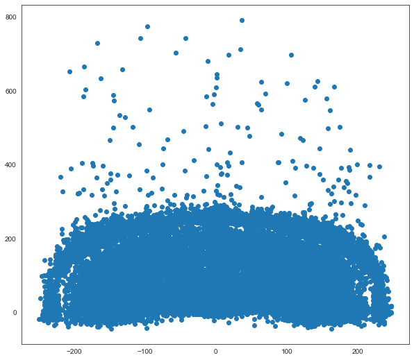

As seen above, the distribution of the data points are formed like an arc shape. And it was expected that this must be similar to the half court basketball aerial/top view. To appreciate more, let's draw a court lines onto our chart. For more information about the creation of basketball court outline, just visit this [link](http://savvastjortjoglou.com/nba-shot-sharts.html).

### Draw a court

Here is now our half court basketball. Let's apply our data to the template.

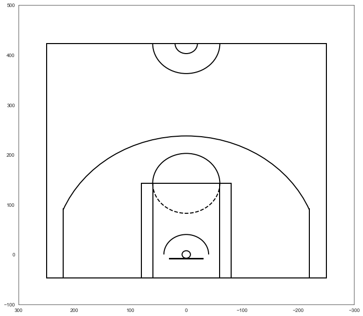

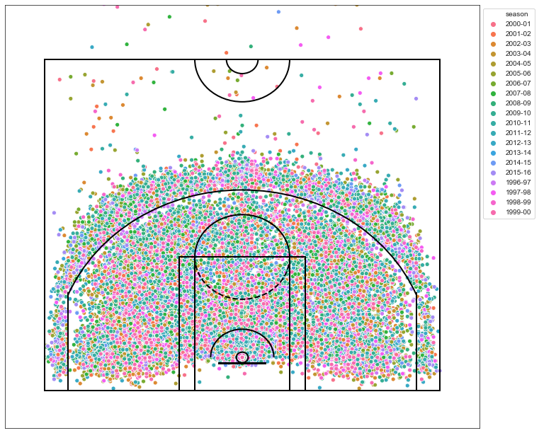

Visualization becomes more interesting. And, some of the data points are out of the said outline, this is because some of the shots taken by `Kobe Bryant` were `Buzzer Beater`. Since the distribution itself is congested, let's filter out the shots made on seasonal basis. Let's start with the time when `Kobe Bryant` was drafted on year `1996`. To give a short history, he was drafted by `Charlotte`, which his original team. However, for some reason, the management was immediately decided to trade him to `Los Angeles Lakers`.

**Note:** I'll not cover all the season, but I'll discuss the important and highlight season. For the next following plots, `red` and `blue` dots refers to missed and made shots.

### First Season ( 1996- 1997 )

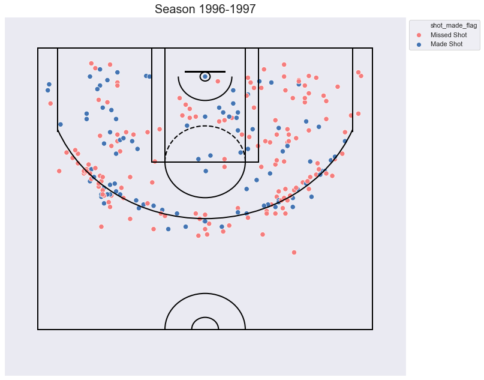

During his first season, it can be seen that all of his shots are somehow working at any part of the court. He accumulated more missed than made shot. Since `Kobe Bryant` is a right-handed player, he prefer to shoot or drive the ball from the right side of the court. As we notice, he tried to shoot the ball farthest from 3pt line but he missed it. Moreover, throughout this season, he wasn't known as a good player yet, but a bench player who consumed more time by sitting. This is okay since this is just a beginning of his journey. Let's see how `Kobe Bryant` strive and grow as the season progress.

### Season 1999-2000

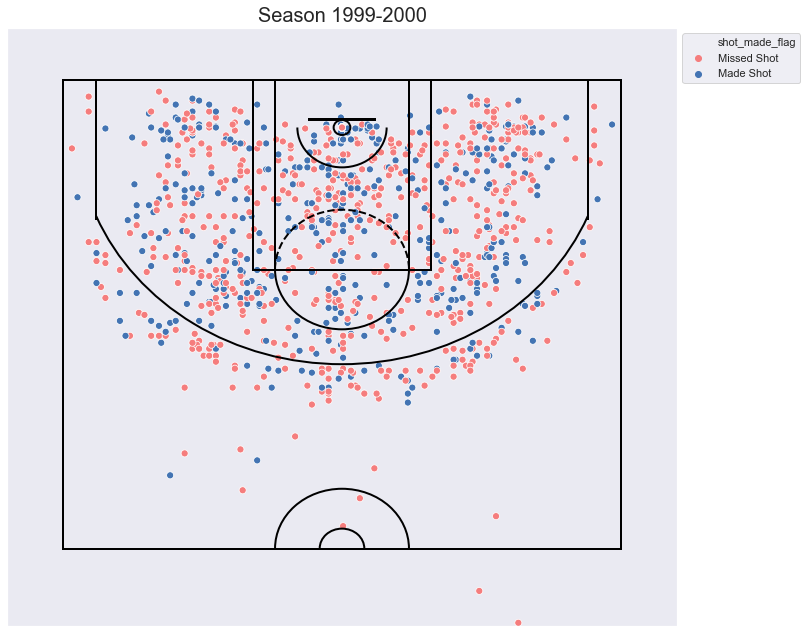

Upon taking four NBA seasons, during season 1999-2000, `Kobe Bryant` was started to show up his skills. As we notice, he did more inside and outside shooting. The distribution of made shot can be observed anywhere from the court. Surprisingly, it can be seen that two of his `Long Distance Shot` are made.

On the other hand, there is a significant increase on his average field goal percentage `from (1996) 41.7% to (1999) 46.8%` with average season points of `from (1996) 7.6 to (1999) 22.5`. His improved performance leads to many achievements.

- First `NBA champion` ,
- First `more than 20 AVG points`,
- First `defensive player`.

Reference:  
For achievements visit this [link](https://ftw.usatoday.com/2016/04/ranking-all-20-seasons-of-kobe-bryant-career-from-best-to-worst) and for his stats go [here](https://www.basketball-reference.com/players/b/bryanko01.html).

### Season 2004-2005

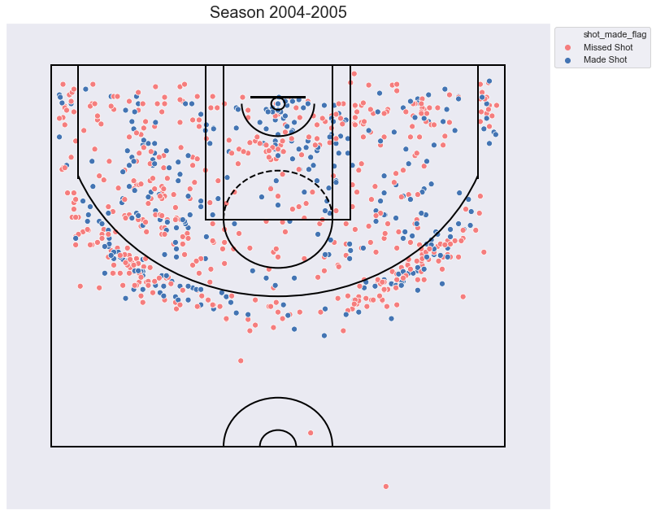

From season 2004-2005, the distribution of the data points slightly decreases. Also, this is the first time of Los Angeles Lakers to be excluded in playoffs since 1993. I think these are some of the reasons why Lakers coudn't make it to postseason:

- `Kobe Bryant` missed 16 games due to his severe sprain ankle.
- His best partner `Shaquille O'Neal` was traded to Miami.

Thus, the value and importance of these two players affect the overall performance of the Lakers.

For reference visit this [link](http://projects.latimes.com/lakers/season/2004-2005/).

### Season 2005-2006

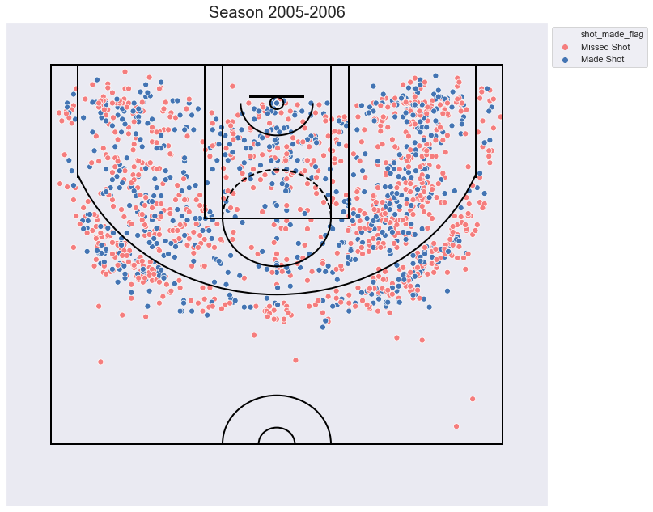

During season 2005-2006, `Kobe Bryant` back to its original shape making him to take more inside and outside shots. Actually, he made 81 points against the Raptors and 62 points against Mavericks ( in just three quarters ). Personally speaking, this is the perfect season for `Kobe Bryant`. However, they had still beaten by a powerful `Phoenix` in 7th western conference.

Due to his extremely good performance, `Kobe Bryant` received another awards:

- First `Scoring Leader`
- Fourth `All-NBA First Team`
- Second `All-Defensive First Team`

For reference visit these links:

- [Playoffs](https://www.google.com/search?rlz=1C1GCEA_enPH859PH859&q=who+beat+lakers+in+2005-2006+playoffs&spell=1&sa=X&ved=2ahUKEwjjxpmpj6XnAhXqFqYKHfkTCPYQBSgAegQIEhAm&biw=1920&bih=969#sie=t;/m/0jmk7;3;/m/05jvx;mt;fp;1)
- [Stats](https://www.landofbasketball.com/nba_players/b/kobe_bryant.htm)

### Season 2013-2014

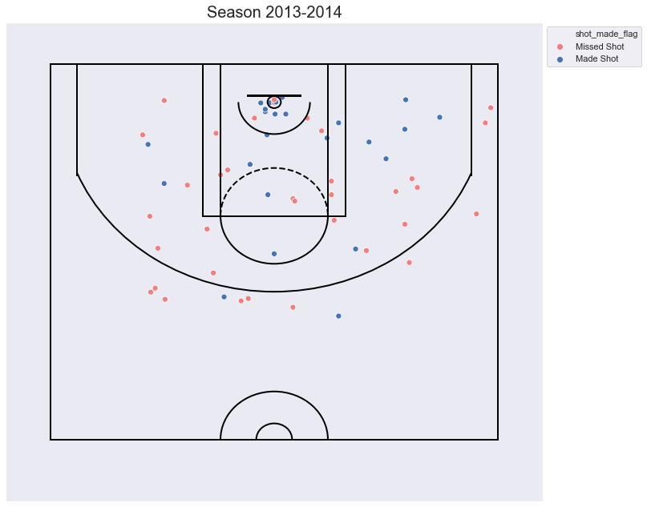

The distribution of the data points during this season seems significantly decreased as to compare with his previous seasons. `Kobe Bryant` shows everyone on how he's very passionate in basketball. During his game against `Golden State Warriors`, in 3rd quarter, `Kobe Bryant` sadly groaning because of knee injury. Even he felt bad and uncomfortable because of his injury, he still wanted to continue and play the game. His team let him to continue the game and at the end, they lost but he still manage to score 34 points despite his miserable injury.

Moreover, based on this [link](https://edition.cnn.com/2013/04/13/sport/kobe-bryant-injury/index.html), Lakers announced that `Kobe Bryant` torn his achilles and will not able to play the rest of the season.

For the highlights of injured `Kobe Bryant` against `GSW Warriors` watch this [video](https://www.youtube.com/watch?v=zKiQsg-8nEM).

### Season 2015-16

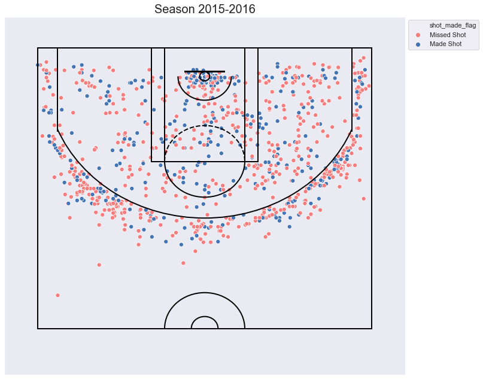

After recovering from back-to-back serious injuries, `Kobe Bryant` decided to play for the last time. This season is the last and a worst season for him with 35.4% shooting around the court and 28.4% shooting from beyond the arc (3pt). This is actually noticeable from the distribution wherein the red dots almost dominate the blue dots. Interestingly, this [article](https://ftw.usatoday.com/2016/04/nba-los-angeles-lakers-kobe-bryant-stats-worst-nba-season-superstar-hall-of-famer-ever) proved the distribution. It can be seen that the data points are concentrated around the 3pt line and mostly are missed shots. In other words, `Kobe Bryant` had been easily jack up by any player that causes him to shoot and attempt more 3pt shots.

### Kobe Bryant Average Points Per Season

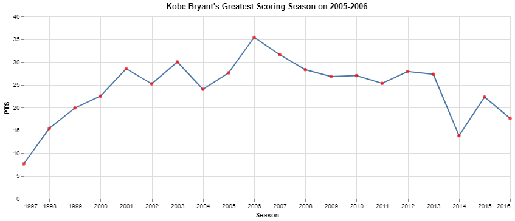

Here is a distribution for `Kobe Bryant` Average PTS per season.

### Kobe Bryant Career Field Goals Attempted (FGA)

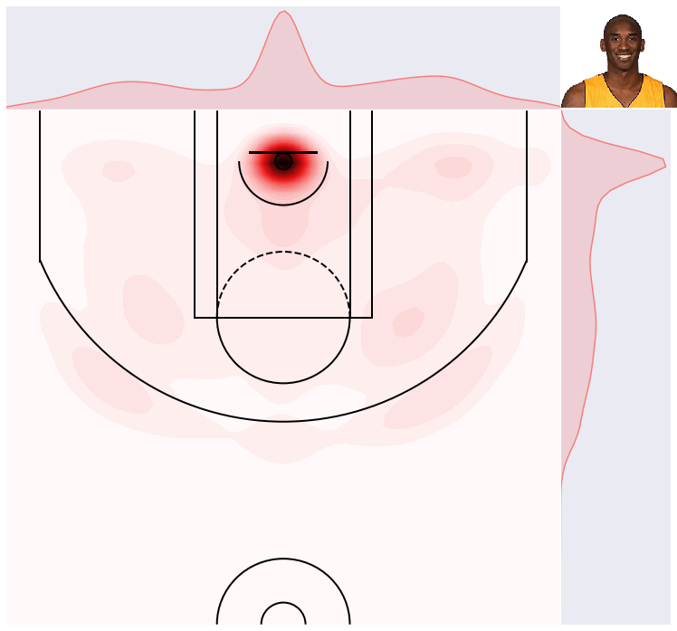

Here is the contour plot of `Kobe Bryant's` FGA for his entire career. Based on plot, we notice that `Kobe Bryant` has these characteristics,

- Both an inside and outside scorer.
- More shots made at the right part of the court.
- Likely to drive the ball instead of long range shot.
- Other assets are mid-range and 3pt shots (above the break 3).
- Inconsistent shooting from corner 3, perhaps because of basketball board reason.

I think that's it. Thank you guys for reading my notebook I hope you learn something new. If you're also a fan of other NBA player, you could do the same way. Hope to see you again to my near future posts.

For the next step, I think its fun if we could build a model that can predict whether `Kobe Bryant` will likely to shoot the ball or not. In this way, even he already passed away, we can still imagine him really shooting the ball.

Thank You Kobe for the Great Legacy. May You Rest Easy!

[figure not shown]